# Evaluación de la probabilidad de ganar en el tenis, bádminton y ping-pong

# 1 Resumen del trabajo

**La pregunta.** Roger Federer ganó el 80 % de sus 1526 partidos, pero solo el 54 % de los puntos que jugó. ¿Cómo pudo ganar tantos partidos con ese porcentaje de puntos?

**Objetivo.** Estudiar cómo varía la probabilidad de ganar un partido cuando cambia la probabilidad de ganar un punto.

**Método.** Para ello, se simulan miles de partidos de tenis, bádminton y ping-pong; punto a punto usando números aleatorios entre 0 y 1: el jugador A gana cada punto con probabilidad ‘p’ y el jugador B con ‘1 - p’. El porcentaje de partidos que gana A es la estimación de su probabilidad de ganar el partido. Se repite para valores de ‘p’ entre 0.40 y 0.60.

**Reglas modeladas.**

- **Tenis:** partido al mejor de 5 sets. Un juego se gana a 4 puntos con 2 de diferencia, un set a 6 juegos con 2 de diferencia, y si se llega a 6-6 se juega un tie-break a 7 puntos (con 2 de diferencia).
- **Bádminton:** partido al mejor de 3 sets. Cada set se juega a 21 puntos con 2 de diferencia, y quien llega a 30 puntos gana el set.
- **Ping-pong:** partido al mejor de 5 sets. Cada set se juega a 11 puntos con 2 de diferencia, sin tope de puntos.

**Resultado principal: una ventaja pequeña se amplifica mucho.** En el tenis, el modelo da aproximadamente estos resultados:

| Puntos ganados (‘p’) | 0.50 | 0.51 | 0.52 | 0.53 | 0.54 | 0.55 | 0.56 |
| --- | --- | --- | --- | --- | --- | --- | --- |
| Partidos ganados | 50 % | 64 % | 75 % | 85 % | 91 % | 95 % | 98 % |

Pasar de ganar el 50 % de los puntos a ganar el 55 % hace que la probabilidad de ganar el partido suba del 50 % al 95 %. La razón es que un partido de tenis son cientos de puntos, y la pequeña ventaja de cada uno se acumula juego a juego y set a set.

**Un matiz sobre Federer.** Con ‘p = 0.54’ constante, el modelo da en torno al 91 % de partidos ganados, más que el 80 % real (con ese porcentaje de victorias el modelo correspondería a ‘p ≈ 0.525’). La diferencia es esperable, porque el modelo es una simplificación: supone que ‘p’ es la misma contra cualquier rival y que los puntos son independientes entre sí. En la realidad el 54 % es un promedio de muchos rivales, y los puntos no pesan lo mismo en todo momento. El modelo muestra matemáticamente una realidad conocida en el mundo del tenis, pese a su larga carrera plagada de éxitos, Roger Federer era comúnmente conocido por jugar peor en puntos importantes y por tanto perder algunos partidos que debería haber ganado. Es el jugador que ostenta el record de más partidos perdidos habiendo ganado más puntos que el adversario. En el modelo avanzado podemos observar que si se ajusta la ‘p=54’ con una ‘desventaja’ de -0.05 en puntos de presión, se deberían ganar aproximadamente el 80% de los partidos, ejemplificando así a jugadores como Federer. Aun así, el modelo explica la idea general: ganar un poco más de la mitad de los puntos basta para ganar la gran mayoría de los partidos.

**Relación con las transiciones de fase.** Aquí ‘p’ actúa como el *parámetro de control* y la probabilidad de ganar el partido como el *parámetro de orden*. El valor crítico está en ‘p = 0.50’: la curva es continua, pero cambia muy rápido en una franja estrecha alrededor de ese valor. En bádminton y ping-pong la curva es menos pronunciada, porque se juegan menos puntos y la ventaja tiene menos tiempo para acumularse (se puede comprobar en la simulación).

**Bola extra: puntos normales y puntos decisivos.** Un jugador puede ganar un partido habiendo perdido más puntos que su rival, porque no todos los puntos valen lo mismo. Para simularlo como proceso estadístico, el modelo distingue dos probabilidades: ‘p1’ para los puntos normales y ‘p2’ para los decisivos (deuce, ventaja y todos los puntos del tie-break). En la simulación, ‘p1’ es el slider de ‘p’ y ‘p2 = p1 + ventaja en puntos de presión’. Por ejemplo, con ‘p = 0.50’ y una ventaja positiva en los puntos decisivos, el jugador A gana más del 50 % de los partidos aunque en los puntos normales esté igualado.

**Resultados que se obtienen.**

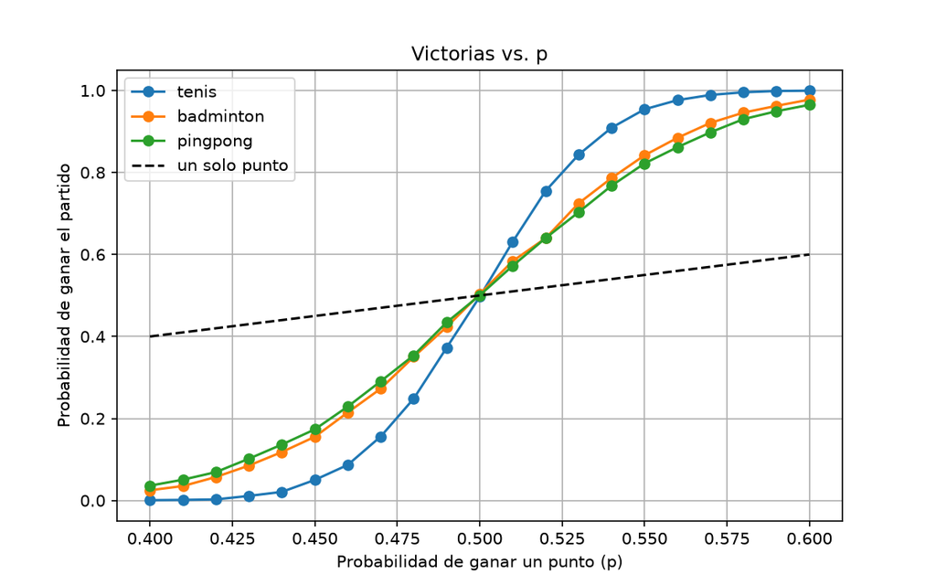

**Cómo está hecho.** El proyecto se divide en dos partes relacionadas: un archivo con código Python que simula y calcula los resultados de los partidos y un archivo ‘.qmd’ que incorpora JavaScript para presentar esos resultados en una página HTML interactiva. Esta separación permite realizar los cálculos una sola vez al generar el documento y después cambiar los controles de la página sin volver a simular miles de partidos cada vez.

# 2 Simulación

Deporte:

Probabilidad de ganar un punto (p):

Ventaja en puntos de presión (solo tenis):

*La línea discontinua gris es la referencia de un partido a un solo punto: ahí la probabilidad de ganar sería igual a 'p'.*

# 3 Código

[Enlace al repositorio de Github](https://github.com/SportLab-Parable/ProbabilidadGanarTenis)

[LinkedIn](https://www.linkedin.com/company/sportlab-parable)